# Barbell Efficiency Prediction

Clemens

7/12/2020

# Executive Summary

Using devices such as Jawbone Up, Nike FuelBand, and Fitbit it is now possible to collect a large amount of data about personal activity relatively inexpensively. These type of devices are part of the quantified self movement – a group of enthusiasts who take measurements about themselves regularly to improve their health, to find patterns in their behavior, or because they are tech geeks. One thing that people regularly do is quantify how much of a particular activity they do, but they rarely quantify how well they do it.

In this project, we will use data from accelerometers on the belt, forearm, arm, and dumbell of 6 participants. The were asked to perform barbell lifts correctly and incorrectly in 5 different ways. We will pick the best model to predict how these barbell movements were executed (correctly or incorrectly). More information an the dataset available from the website here: http://groupware.les.inf.puc-rio.br/har

Levels: A, B, C, D, E exactly according to the specification (Class A) throwing the elbows to the front (Class B) lifting the dumbbell only halfway (Class C) lowering the dumbbell only halfway (Class D) throwing the hips to the front (Class E).

# Data Analysis

## Load data and packages

```r
library(caret)
library(dplyr)
```

```r
library(corrplot)
library(rpart)
library(randomForest)
library(rattle)
train.dat0 = read.csv("https://d396qusza40orc.cloudfront.net/predmachlearn/pml-training.csv", na.strings = c("", "NA", "#DIV/0!", " ")) #make all blank strings NA

valid.dat = read.csv("https://d396qusza40orc.cloudfront.net/predmachlearn/pml-testing.csv", na.strings = c("", "NA", "#DIV/0!"," "))

dim(train.dat0)
```

```
## [1] 19622   160
```

## Exploratory Data Analysis

Next we’ll try and narrow down the dataset to relevant variables using the following methods: variables with near zero variance, most NAs, and removing index columns.

```r
set.seed(3000)
inTrain <- createDataPartition(y=train.dat0$classe,p=.7, list = FALSE)
train.dat <- train.dat0[inTrain,]
test.dat <- train.dat0[-inTrain,]

dim(train.dat)
```

```
## [1] 13737   160
```

```r
dim(test.dat)
```

```
## [1] 5885  160
```

```r
# stripping out variables with low (near zero) variance and therefor low effect on classe
nzv <- nearZeroVar(train.dat)
train.dat1 <- train.dat[,-nzv]
nzv2 <- nearZeroVar(test.dat)
test.dat1 <- test.dat[,-nzv]

#rmoving variables that are almost all (95%) NAs
mostlyNA <- sapply(train.dat1, function(x) mean(is.na(x))) > 0.95
train.dat1 <- train.dat1[ ,mostlyNA == FALSE]
mostlyNA2 <- sapply(test.dat1, function(x) mean(is.na(x))) > 0.95
test.dat1 <- test.dat1[ ,mostlyNA == FALSE]

#remove first 7 rows
train.dat1 <- train.dat1[,-c(1:7)]
test.dat1 <- test.dat1[,-c(1:7)]

dim(train.dat1)
```

```
## [1] 13737    52
```

```r
dim(test.dat1)
```

```
## [1] 5885   52
```

```r
y <- train.dat1[,52] #creating x and y variables to help with random forest runtime
x <- train.dat1[,-52]
```

Through the steps above we have narrowed down to 52 variables from 160. This makes sense after scanning the original dataset that had a lot of blank observations.

Since we still have a relatively large number of variables to look at, I’ll use the corrplot library to plot a corellelagram to visualize which have the most influence. https://www.r-bloggers.com/correlogram-in-r-how-to-highlight-the-most-correlated-variables-in-a-dataset/

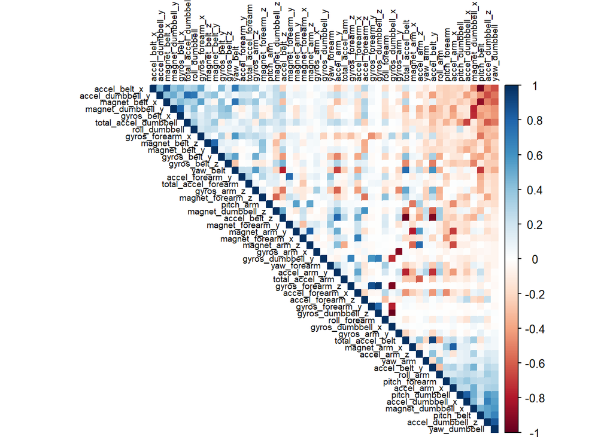

```r
cor.matrix <- cor(train.dat1[, -52])
corrplot(cor.matrix, order = "FPC", method = "color", type = "upper", tl.cex = .6, tl.col = rgb(0, 0, 0)) #.6 appears to be the best font size
```

```r
correlated <- findCorrelation(cor.matrix, cutoff = .8)
names(train.dat1[correlated])
```

```
##  [1] "accel_belt_z"     "accel_dumbbell_z" "accel_belt_y"     "accel_belt_x"
##  [5] "pitch_belt"       "accel_arm_x"      "accel_dumbbell_x" "magnet_arm_y"
##  [9] "gyros_dumbbell_x" "gyros_forearm_y"  "gyros_dumbbell_z" "gyros_arm_x"
```

Using the corrplot library we can narrow down to the top 12 correlated variables (using 0.8 cutoff)

## Training the Model

*I’ll run these 3 classification models learned in the course to compare how well they predict the correct barbell class variable. 1. tree classification model 2. random forest, and 3. boosting*

### Tree Classification Model

[figure not shown]

```r
set.seed(900)
fit.tree <- train(classe ~., method = "rpart", data = train.dat1)
fancyRpartPlot(fit.tree$finalModel)
```

```r
pred.tree <- predict(fit.tree, test.dat1, type = "raw")
conf.tree <- confusionMatrix(pred.tree, test.dat1$classe)
conf.tree
```

```
## Confusion Matrix and Statistics
##
##           Reference
## Prediction    A    B    C    D    E
##          A 1013  170   24   54   19
##          B  224  684  121  167  343
##          C  330  208  860  295  304
##          D  105   77   21  448  105
##          E    2    0    0    0  311
##
## Overall Statistics
##
##                Accuracy : 0.5635
##                  95% CI : (0.5507, 0.5762)
##     No Information Rate : 0.2845
##     P-Value [Acc > NIR] : < 2.2e-16
##
##                   Kappa : 0.4526
##
##  Mcnemar's Test P-Value : < 2.2e-16
##
## Statistics by Class:
##
##                      Class: A Class: B Class: C Class: D Class: E
## Sensitivity            0.6051   0.6005   0.8382  0.46473  0.28743
## Specificity            0.9366   0.8198   0.7660  0.93741  0.99958
## Pos Pred Value         0.7914   0.4444   0.4306  0.59259  0.99361
## Neg Pred Value         0.8565   0.8953   0.9573  0.89940  0.86163
## Prevalence             0.2845   0.1935   0.1743  0.16381  0.18386
## Detection Rate         0.1721   0.1162   0.1461  0.07613  0.05285
## Detection Prevalence   0.2175   0.2615   0.3393  0.12846  0.05319
## Balanced Accuracy      0.7709   0.7102   0.8021  0.70107  0.64351
```

### Random Forest Classification Model

```r
set.seed(400)
fitControl <- trainControl(method = "cv",number = 3,verboseIter=FALSE)
fit.rf <- train(x,y, method = "rf", data = train.dat1, trControl = fitControl)
fit.rf$finalModel
```

```
##
## Call:
##  randomForest(x = x, y = y, mtry = param$mtry, data = ..1)
##                Type of random forest: classification
##                      Number of trees: 500
## No. of variables tried at each split: 26
##
##         OOB estimate of  error rate: 0.68%
## Confusion matrix:
##      A    B    C    D    E class.error
## A 3900    4    1    0    1 0.001536098
## B   19 2631    7    0    1 0.010158014
## C    0    9 2376   11    0 0.008347245
## D    0    1   26 2222    3 0.013321492
## E    0    0    3    8 2514 0.004356436
```

```r
predict.rf <- predict(fit.rf, newdata = test.dat1)
cm.rf <- confusionMatrix(predict.rf, test.dat1$classe)
cm.rf
```

```
## Confusion Matrix and Statistics
##
##           Reference
## Prediction    A    B    C    D    E
##          A 1674    6    0    0    0
##          B    0 1123    3    0    0
##          C    0    8 1022   12    1
##          D    0    0    1  952    7
##          E    0    2    0    0 1074
##
## Overall Statistics
##
##                Accuracy : 0.9932
##                  95% CI : (0.9908, 0.9951)
##     No Information Rate : 0.2845
##     P-Value [Acc > NIR] : < 2.2e-16
##
##                   Kappa : 0.9914
##
##  Mcnemar's Test P-Value : NA
##
## Statistics by Class:
##
##                      Class: A Class: B Class: C Class: D Class: E
## Sensitivity            1.0000   0.9860   0.9961   0.9876   0.9926
## Specificity            0.9986   0.9994   0.9957   0.9984   0.9996
## Pos Pred Value         0.9964   0.9973   0.9799   0.9917   0.9981
## Neg Pred Value         1.0000   0.9966   0.9992   0.9976   0.9983
## Prevalence             0.2845   0.1935   0.1743   0.1638   0.1839
## Detection Rate         0.2845   0.1908   0.1737   0.1618   0.1825
## Detection Prevalence   0.2855   0.1913   0.1772   0.1631   0.1828
## Balanced Accuracy      0.9993   0.9927   0.9959   0.9930   0.9961
```

Here’s a view of the plot for cross-validation:

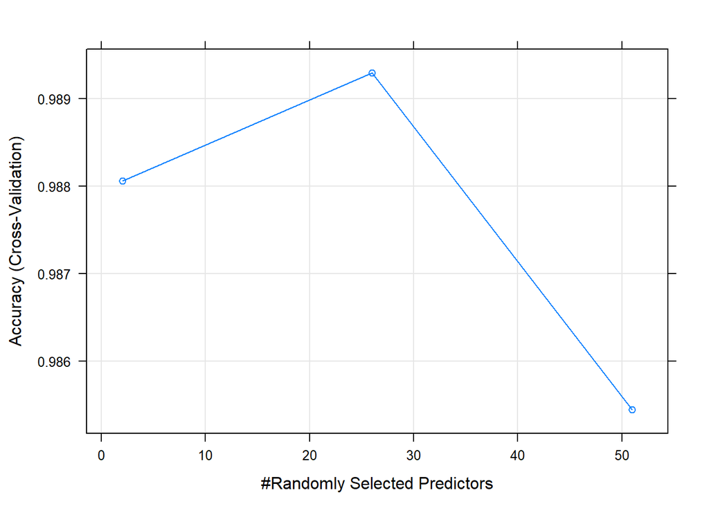

```r
plot(fit.rf)
```

### Boosting Classification Model

```r
set.seed(500)
control.boost <- trainControl(method = "repeatedcv", number = 5, repeats = 1)
fit.boost <- train(classe ~., method = "gbm", data = train.dat1, trControl = control.boost, verbose=FALSE)
fit.boost$finalModel
```

```
## A gradient boosted model with multinomial loss function.
## 150 iterations were performed.
## There were 51 predictors of which 51 had non-zero influence.
```

```r
pred.boost <- predict(fit.tree, newdata = test.dat1)
conf.boost <- confusionMatrix(pred.boost, test.dat1$classe)
conf.boost
```

[output not shown]